# Estimación Bayesiana de la Brecha Salarial de Género (Modelo Log-normal)

## 1 1. Flujo de Trabajo en Modelado Bayesiano con Stan y R

El proceso de modelado bayesiano en Stan y R sigue una serie de pasos que ayudan a organizar el razonamiento estadístico y la implementación computacional. Aquí describimos el flujo general de trabajo:

### 1.1 Identificación de las hipótesis y el modelo generativo

- Variable de interés: salario de individuos.
- Queremos estimar las diferencias entre hombres y mujeres en salarios.Ho: No hay diferencias
- Sabemos que los salarios no siguen una distribución normal simétrica, sino que están sesgados a la derecha.

### 1.2 Especificación del Modelo Generativo

- ¿Qué sabemos sobre la distribución estadística de los salarios?
- En lugar de modelar directamente el salario, modelamos el **logaritmo del salario**, que suele estar más cerca de una distribución normal.
- Esto implica asumir que `log(salario)` sigue una distribución normal, lo que equivale a suponer que el salario tiene una distribución log-normal.

Suponemos que los datos observados siguen una distribución log-normal, es decir, modelamos el logaritmo del salario:

$$\log(\text{wage}_i) \sim \mathcal{N}(\alpha + \beta \cdot
\text{female}_i,\ \sigma^2)$$

donde: - $\alpha$ es el log-salario promedio para los hombres ($\text{female}_i = 0$), - $\beta$ representa la diferencia entre hombres y mujeres en el logaritmo del salario, - $\sigma$ es la desviación estándar del log-salario.

### 1.3 Asignamos las siguientes distribuciones a priori a los parámetros:

$$\begin{aligned}
\alpha &\sim \mathcal{N}(7,\ 2^2) \\
\beta &\sim \mathcal{N}(0,\ 0.1^2) \\
\sigma &\sim \text{Cauchy}^{+}(0,\ 2)
\end{aligned}$$

donde $\text{Cauchy}^{+}$ indica que la distribución Cauchy está truncada en $\sigma > 0$.

### 1.4 Justificación de las Distribuciones A Priori

Las distribuciones a priori fueron elegidas para reflejar conocimiento moderado e incorporar información contextual razonable sin ser excesivamente restrictivas.

- **Prior para $\alpha$ (nivel base del log-salario):**

  $$\alpha \sim \mathcal{N}(7,\ 2^2)$$

  $$\beta \sim \mathcal{N}(0,\ 0.1^2)$$

  Este prior es **informativo** y expresa la creencia de que, *a priori*, es poco probable que el efecto de género sea muy grande. En términos de salario relativo:

  $$\exp(0.1) \approx 1.105, \quad \exp(-0.1) \approx 0.905$$

  Es decir, se espera que la diferencia de hombres y mujeres de salario entre -10% y +10% aproximadamente, antes de ver los datos. Esta prior representa escepticismo hacia efectos grandes, lo cual es útil en contextos con muestras pequeñas, ya que reduce la probabilidad de falsos positivos.
- **Prior para $\sigma$ (desviación estándar del log-salario):**

  $$\sigma \sim \text{Cauchy}^+(0,\ 2)$$

  El prior Cauchy positivo es una elección común para parámetros de escala porque permite valores pequeños, pero también deja abierta la posibilidad de valores grandes (colas pesadas). Es un prior *débilmente informativo* que evita restricciones artificiales sobre la dispersión de los salarios.

### 1.5 Escritura del Modelo en Stan

- Definimos el modelo en términos de `log(wage)`.
- Especificamos priors para los parámetros y el modelo de verosimilitud.

### 1.6 Llamada desde R

- Transformamos los datos (`log(wage)`), creamos la lista para Stan.
- Ajustamos el modelo y analizamos los resultados.

### 1.7 Chequeos predictivos posteriores

- Convergencia
- Capacidad predictiva del modelo

## 3 Código del Modelo en Stan (Log-salario)

En lugar de guardar el modelo en un archivo `.stan`, podemos escribirlo directamente dentro del código y compilarlo con `cmdstan_model(write_stan_file(...))`:

El código de stan tiene **4** bloques y usa la lógica de escritura modular de C++:

- Datos: Variables y características del modelo
- Parámetros: Nombres de los parámetros
- Modelo: Priors y verosimulitud
- Cantidades generadas: Predicción bajo las posteriores

```r
stan_code <- "
data {
  int<lower=0> N;
  vector[N] log_wage;
  vector[N] female;
}
parameters {
  real alpha;
  real beta;
  real<lower=0> sigma;
}
model {
  alpha ~ normal(7, 2);
  beta ~ normal(0, 0.1);
  sigma ~ cauchy(0, 2);

  log_wage ~ normal(alpha + beta .* female, sigma);
}
generated quantities {
  vector[N] log_wage_rep;
  for (i in 1:N) {
    log_wage_rep[i] = normal_rng(alpha + beta * female[i], sigma);
  }
}
"
```

## 4 4. Prior predictive checks:

La simulación desde los priors con Stan es una forma de revisar si los a prioris del modelo generativo producen resultados razonables de la distribución observada.

```r
prior_stan_code <- "
data {
  int<lower=1> N;
  vector[N] female;
}
generated quantities {
  real alpha = normal_rng(7, 2);
  real beta = normal_rng(0, 0.1);
  real sigma = abs(cauchy_rng(0, 2));

  vector[N] log_wage_sim;
  for (i in 1:N) {
    log_wage_sim[i] = normal_rng(alpha + beta * female[i], sigma);
  }
}
"

prior_model <- cmdstan_model(write_stan_file(prior_stan_code))

female_sim <- rbinom(N, 1, 0.5)

sim_prior <- prior_model$sample(
  data = list(N = N, female = female_sim),
  fixed_param = TRUE,
  chains = 1,
  iter_sampling = 1000,
  seed = 123
)
```

[output not shown]

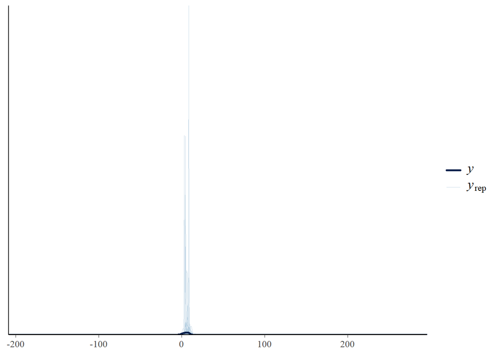

```r
log_wage_sim_draws <- sim_prior$draws("log_wage_sim", format = "matrix")

y_fake <- as.numeric(log_wage_sim_draws[1, ])
ppc_dens_overlay(y = y_fake, yrep = log_wage_sim_draws[1:50, ])
```

## 5 Ajuste del Modelo en R usando `cmdstanr`

Para ajustar el modelo es necesario:

- Pasar los datos a una lista para que stan los lea
- compilar el modelo en cmdstanr (paralelización)
- estimar las posteriores con `model$sample`

```r
stan_data <- list(N = N, log_wage = data$log_wage, female = data$female)
model <- cmdstan_model(write_stan_file(stan_code), cpp_options = list(stan_threads = TRUE))
fit_log <- model$sample(
  data = stan_data,
  chains = 4, #cuantas cadenas
  parallel_chains = 4, #cuantas en paralelo
  threads_per_chain = 2, #cuantas dividas en los núcleos
  iter_sampling = 2000, #total de iteraciones
  iter_warmup = 500, #calentamiento
  seed = 123 #replicabilidad de arranque del algoritmo
)
```

[output not shown]

[output not shown]

[output not shown]

[output not shown]

[output not shown]

[output not shown]

[output not shown]

Valores de los parámetros:

```r
fit_log$print(variables = c("alpha", "beta", "sigma"))
```

```
##  variable  mean median   sd  mad    q5  q95 rhat ess_bulk ess_tail
##     alpha  7.57   7.57 0.05 0.05  7.48 7.64 1.00     4689     4488
##     beta  -0.09  -0.09 0.06 0.06 -0.19 0.01 1.00     4873     4517
##     sigma  0.21   0.20 0.03 0.03  0.17 0.26 1.00     4574     4530
```

## 6 Diagnóstico: Convergencia

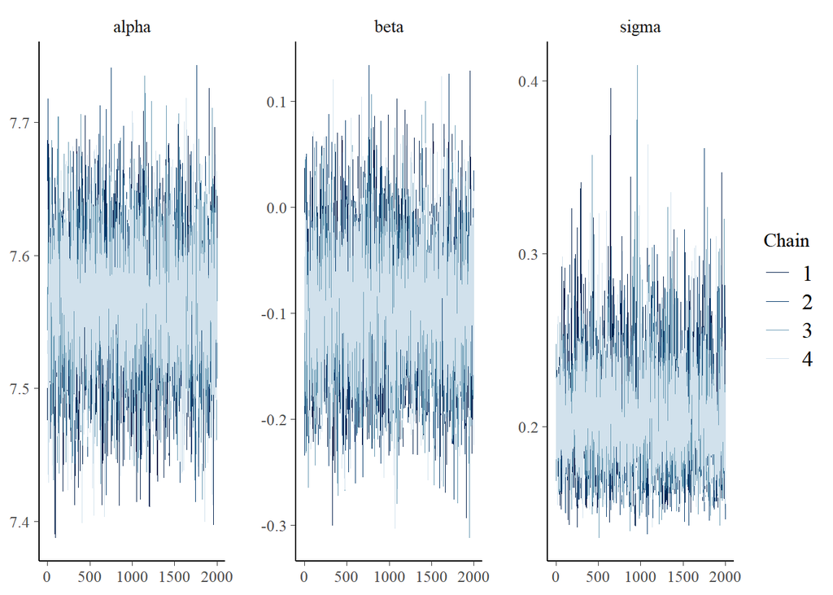

```r
draws_array <- fit_log$draws(variables = c("alpha", "beta", "sigma"))
mcmc_trace(draws_array)
```

## 7 Verificación Posterior Predictiva (PPC)

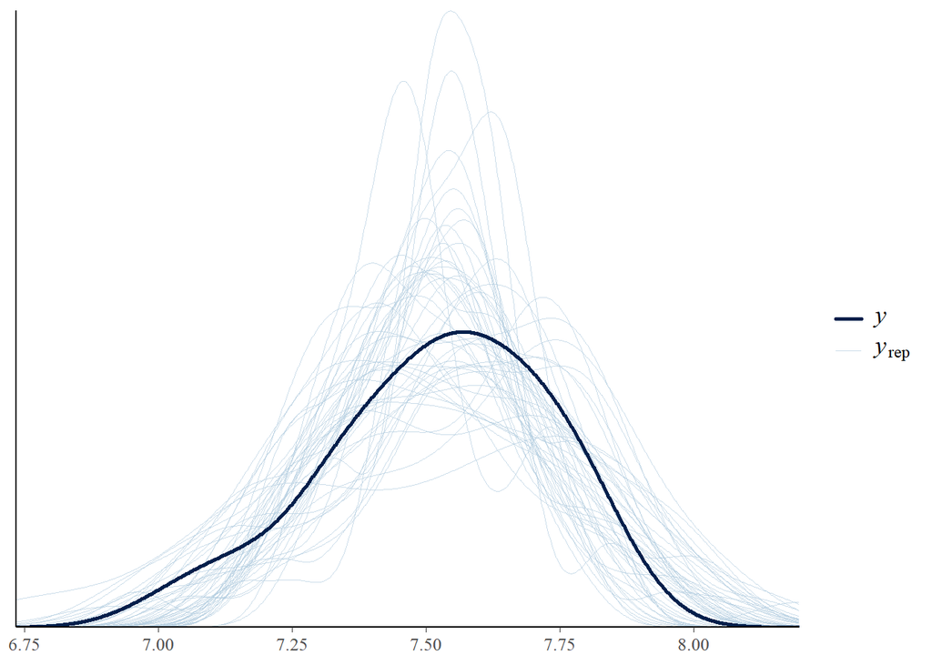

```r
log_wage_rep <- fit_log$draws(variables = "log_wage_rep", format = "matrix")
log_wage_obs <- data$log_wage
ppc_dens_overlay(y = log_wage_obs, yrep = log_wage_rep[1:50, ])
```

## 8 Inferencia

La estimación de `beta` indica la diferencia en el **logaritmo del salario** entre hombres y mujeres. Para interpretarlo en la escala original:

```r
draws <- fit_log$draws(variables = "beta", format = "df")
exp_beta <- exp(draws$beta)
quantile(exp_beta, probs = c(0.025, 0.5, 0.975))
```

```
##      2.5%       50%     97.5%
## 0.8125516 0.9104246 1.0279643
```

El salario de las mujeres es, en mediana, aproximadamente el 91% del salario de los hombres (exp(β) ≈ 0.91).

Hay bastante incertidumbre: el intervalo creíble del 95% va de 81% a 103% del salario masculino.

Dado que el intervalo incluye 1, no hay evidencia clara de una brecha salarial significativa en esta simulación.

## 9 Comparación Frequentista (log-salario)

```r
lm_fit_log <- lm(log(wage) ~ female, data = data)
summary(lm_fit_log)
```

```
##
## Call:
## lm(formula = log(wage) ~ female, data = data)
##
## Residuals:
##      Min       1Q   Median       3Q      Max
## -0.45804 -0.11192  0.04647  0.11481  0.35268
##
## Coefficients:
##             Estimate Std. Error t value Pr(>|t|)
## (Intercept)  7.59276    0.05090 149.170   <2e-16 ***
## female      -0.14738    0.07198  -2.047   0.0501 .
## ---
## Signif. codes:  0 '***' 0.001 '**' 0.01 '*' 0.05 '.' 0.1 ' ' 1
##
## Residual standard error: 0.1971 on 28 degrees of freedom
## Multiple R-squared:  0.1302, Adjusted R-squared:  0.09915
## F-statistic: 4.192 on 1 and 28 DF,  p-value: 0.05011
```

## 11 Preguntas

- ¿Cómo interpretamos el efecto `beta` bajo cada enfoque?
- ¿Qué rol juega la prior? ¿Puede evitar que saquemos conclusiones precipitadas?
- ¿Cómo influye el tamaño muestral en la credibilidad del efecto observado?
- ¿Cuándo sería razonable usar una prior informativa?

## 12 Elección de malos priors

¿Qué pasa si usamos malos priors a la clásica?

```r
stan_bad_prior <- "
data {
  int<lower=0> N;
  vector[N] log_wage;
  vector[N] female;
}
parameters {
  real alpha;
  real beta;
  real<lower=0> sigma;
}
model {
  alpha ~ normal(0, 100);  // absurdamente vaga
  beta ~ normal(0, 100);   // absurdamente vaga
  sigma ~ cauchy(0, 10);    // colas extremadamente pesadas

  log_wage ~ normal(alpha + beta .* female, sigma);
}
generated quantities {
  vector[N] log_wage_rep;
  for (i in 1:N) {
    log_wage_rep[i] = normal_rng(alpha + beta * female[i], sigma);
  }
}
"
bad_model <- cmdstan_model(write_stan_file(stan_bad_prior),cpp_options = list(stan_threads = TRUE))

fit_bad <- bad_model$sample(
  data = stan_data,
  chains = 4,
  parallel_chains = 4,
  iter_sampling = 1000,
  threads_per_chain = 2,
  iter_warmup = 500,
  seed = 123
)
```

[output not shown]

[output not shown]

[output not shown]

[output not shown]

[output not shown]

[output not shown]

[output not shown]

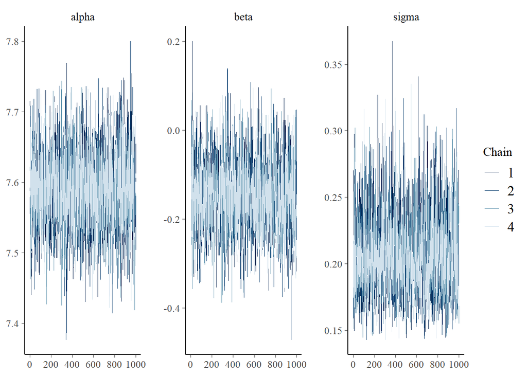

```r
mcmc_trace(fit_bad$draws(c("alpha", "beta", "sigma")))
```

```r
fit_bad$cmdstan_diagnose()
```

```
## Processing csv files: C:/Users/Hector/AppData/Local/Temp/Rtmp8G1VHK/model_7494c8151cce2d141a2ad84ac9974703-202503280636-1-763947.csv, C:/Users/Hector/AppData/Local/Temp/Rtmp8G1VHK/model_7494c8151cce2d141a2ad84ac9974703-202503280636-2-763947.csv, C:/Users/Hector/AppData/Local/Temp/Rtmp8G1VHK/model…
##
## Checking sampler transitions treedepth.
## Treedepth satisfactory for all transitions.
##
## Checking sampler transitions for divergences.
## No divergent transitions found.
##
## Checking E-BFMI - sampler transitions HMC potential energy.
## E-BFMI satisfactory.
##
## Effective sample size satisfactory.
##
## Split R-hat values satisfactory all parameters.
##
## Processing complete, no problems detected.
```

```r
fit_bad$print(variables = c("alpha", "beta", "sigma"))
```

```
##  variable  mean median   sd  mad    q5   q95 rhat ess_bulk ess_tail
##     alpha  7.59   7.59 0.05 0.05  7.50  7.68 1.00     2375     2303
##     beta  -0.15  -0.15 0.08 0.08 -0.27 -0.02 1.00     2332     2337
##     sigma  0.21   0.20 0.03 0.03  0.16  0.26 1.00     2361     2106
```

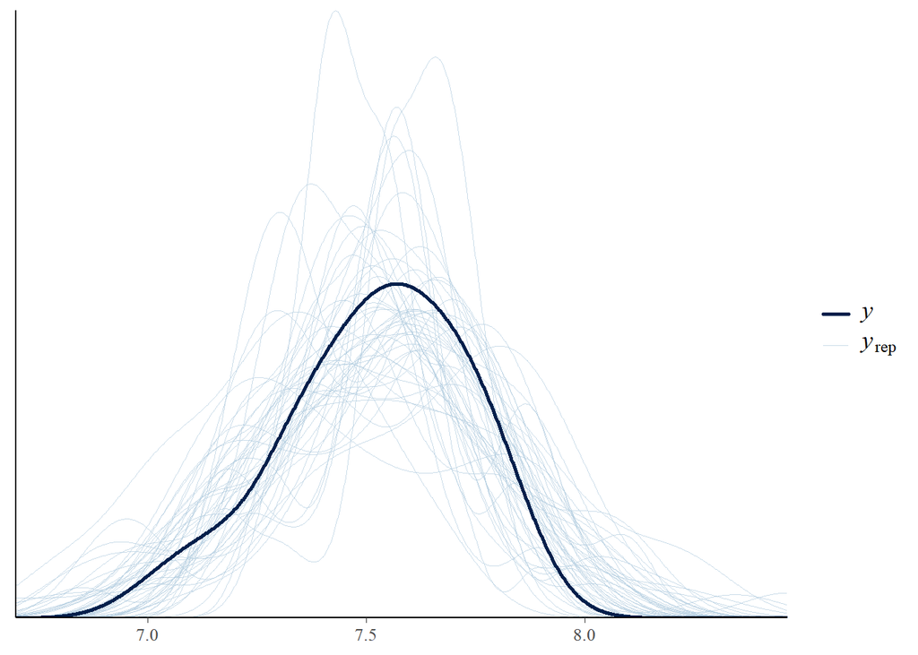

```r
log_wage_rep_bad <- fit_bad$draws("log_wage_rep", format = "matrix")
ppc_dens_overlay(y = data$log_wage, yrep = log_wage_rep_bad[1:50, ])
```